# Risk Factor Analysis

## Outcome Variable

**Outcome Variable:** ever_wasted

## Predictor Variables

**Intervention Variable:** parity

**Adjustment Set:**

- arm
- W_mage
- meducyrs
- feducyrs
- hhwealth_quart
- W_mhtcm
- vagbrth
- W_nrooms
- impfloor
- impsan
- safeh20
- delta_W_mage
- delta_meducyrs
- delta_feducyrs
- delta_hhwealth_quart
- delta_W_mhtcm
- delta_vagbrth
- delta_W_nrooms
- delta_impfloor
- delta_impsan
- delta_safeh20

## Stratifying Variables

The analysis was stratified on these variable(s):

- agecat
- studyid
- country

## Data Summary

| agecat | studyid | country | parity | ever_wasted | n_cell | n |
| --- | --- | --- | --- | --- | --- | --- |
| 0-24 months | ki1000304b-SAS-CompFeed | INDIA | 1 | 0 | 273 | 1513 |
| 0-24 months | ki1000304b-SAS-CompFeed | INDIA | 1 | 1 | 175 | 1513 |
| 0-24 months | ki1000304b-SAS-CompFeed | INDIA | 2 | 0 | 219 | 1513 |
| 0-24 months | ki1000304b-SAS-CompFeed | INDIA | 2 | 1 | 135 | 1513 |
| 0-24 months | ki1000304b-SAS-CompFeed | INDIA | 3+ | 0 | 393 | 1513 |
| 0-24 months | ki1000304b-SAS-CompFeed | INDIA | 3+ | 1 | 318 | 1513 |
| 0-24 months | ki1000304b-SAS-FoodSuppl | INDIA | 1 | 0 | 51 | 397 |
| 0-24 months | ki1000304b-SAS-FoodSuppl | INDIA | 1 | 1 | 26 | 397 |
| 0-24 months | ki1000304b-SAS-FoodSuppl | INDIA | 2 | 0 | 46 | 397 |
| 0-24 months | ki1000304b-SAS-FoodSuppl | INDIA | 2 | 1 | 46 | 397 |
| 0-24 months | ki1000304b-SAS-FoodSuppl | INDIA | 3+ | 0 | 112 | 397 |
| 0-24 months | ki1000304b-SAS-FoodSuppl | INDIA | 3+ | 1 | 116 | 397 |
| 0-24 months | ki1017093b-PROVIDE | BANGLADESH | 1 | 0 | 163 | 700 |
| 0-24 months | ki1017093b-PROVIDE | BANGLADESH | 1 | 1 | 108 | 700 |
| 0-24 months | ki1017093b-PROVIDE | BANGLADESH | 2 | 0 | 170 | 700 |
| 0-24 months | ki1017093b-PROVIDE | BANGLADESH | 2 | 1 | 74 | 700 |
| 0-24 months | ki1017093b-PROVIDE | BANGLADESH | 3+ | 0 | 121 | 700 |
| 0-24 months | ki1017093b-PROVIDE | BANGLADESH | 3+ | 1 | 64 | 700 |
| 0-24 months | ki1066203-TanzaniaChild2 | TANZANIA, UNITED REPUBLIC OF | 1 | 0 | 624 | 2357 |
| 0-24 months | ki1066203-TanzaniaChild2 | TANZANIA, UNITED REPUBLIC OF | 1 | 1 | 197 | 2357 |
| 0-24 months | ki1066203-TanzaniaChild2 | TANZANIA, UNITED REPUBLIC OF | 2 | 0 | 583 | 2357 |
| 0-24 months | ki1066203-TanzaniaChild2 | TANZANIA, UNITED REPUBLIC OF | 2 | 1 | 188 | 2357 |
| 0-24 months | ki1066203-TanzaniaChild2 | TANZANIA, UNITED REPUBLIC OF | 3+ | 0 | 592 | 2357 |
| 0-24 months | ki1066203-TanzaniaChild2 | TANZANIA, UNITED REPUBLIC OF | 3+ | 1 | 173 | 2357 |
| 0-24 months | ki1101329-Keneba | GAMBIA | 1 | 0 | 160 | 1989 |
| 0-24 months | ki1101329-Keneba | GAMBIA | 1 | 1 | 80 | 1989 |
| 0-24 months | ki1101329-Keneba | GAMBIA | 2 | 0 | 138 | 1989 |
| 0-24 months | ki1101329-Keneba | GAMBIA | 2 | 1 | 76 | 1989 |
| 0-24 months | ki1101329-Keneba | GAMBIA | 3+ | 0 | 887 | 1989 |
| 0-24 months | ki1101329-Keneba | GAMBIA | 3+ | 1 | 648 | 1989 |

[output cut: 168 more lines]

The following strata were considered:

- agecat: 0-24 months, studyid: ki1000304b-SAS-CompFeed, country: INDIA
- agecat: 0-24 months, studyid: ki1000304b-SAS-FoodSuppl, country: INDIA
- agecat: 0-24 months, studyid: ki1017093b-PROVIDE, country: BANGLADESH
- agecat: 0-24 months, studyid: ki1066203-TanzaniaChild2, country: TANZANIA, UNITED REPUBLIC OF
- agecat: 0-24 months, studyid: ki1101329-Keneba, country: GAMBIA
- agecat: 0-24 months, studyid: ki1113344-GMS-Nepal, country: NEPAL
- agecat: 0-24 months, studyid: ki1126311-ZVITAMBO, country: ZIMBABWE
- agecat: 0-24 months, studyid: ki1135781-COHORTS, country: GUATEMALA
- agecat: 0-24 months, studyid: ki1135781-COHORTS, country: INDIA
- agecat: 0-24 months, studyid: ki1135781-COHORTS, country: PHILIPPINES
- agecat: 0-24 months, studyid: kiGH5241-JiVitA-3, country: BANGLADESH
- agecat: 0-6 months, studyid: ki1000304b-SAS-CompFeed, country: INDIA
- agecat: 0-6 months, studyid: ki1000304b-SAS-FoodSuppl, country: INDIA
- agecat: 0-6 months, studyid: ki1017093b-PROVIDE, country: BANGLADESH
- agecat: 0-6 months, studyid: ki1066203-TanzaniaChild2, country: TANZANIA, UNITED REPUBLIC OF
- agecat: 0-6 months, studyid: ki1101329-Keneba, country: GAMBIA
- agecat: 0-6 months, studyid: ki1113344-GMS-Nepal, country: NEPAL
- agecat: 0-6 months, studyid: ki1126311-ZVITAMBO, country: ZIMBABWE
- agecat: 0-6 months, studyid: ki1135781-COHORTS, country: GUATEMALA
- agecat: 0-6 months, studyid: ki1135781-COHORTS, country: INDIA
- agecat: 0-6 months, studyid: ki1135781-COHORTS, country: PHILIPPINES
- agecat: 0-6 months, studyid: kiGH5241-JiVitA-3, country: BANGLADESH
- agecat: 6-24 months, studyid: ki1000304b-SAS-CompFeed, country: INDIA
- agecat: 6-24 months, studyid: ki1000304b-SAS-FoodSuppl, country: INDIA
- agecat: 6-24 months, studyid: ki1017093b-PROVIDE, country: BANGLADESH
- agecat: 6-24 months, studyid: ki1066203-TanzaniaChild2, country: TANZANIA, UNITED REPUBLIC OF
- agecat: 6-24 months, studyid: ki1101329-Keneba, country: GAMBIA
- agecat: 6-24 months, studyid: ki1113344-GMS-Nepal, country: NEPAL
- agecat: 6-24 months, studyid: ki1126311-ZVITAMBO, country: ZIMBABWE
- agecat: 6-24 months, studyid: ki1135781-COHORTS, country: GUATEMALA
- agecat: 6-24 months, studyid: ki1135781-COHORTS, country: INDIA
- agecat: 6-24 months, studyid: ki1135781-COHORTS, country: PHILIPPINES
- agecat: 6-24 months, studyid: kiGH5241-JiVitA-3, country: BANGLADESH

## Methods Detail

We’re interested in the causal parameters $E[Y_a]$ for all values of $a \in \mathcal{A}$. These parameters represent the mean outcome if, possibly contrary to fact, we intervened to set all units to have $A=a$. Under the randomization and positivity assumptions, these are identified by the statistical parameters $\psi_a=E_W[E_{Y|A,W}(Y|A=a,W)]$. In addition, we’re interested in the mean of $Y$, $E[Y]$ under no intervention (the observed mean). We will estimate these parameters by using SuperLearner to fit the relevant likelihood factors – $E_{Y|A,W}(Y|A=a,W)$ and $p(A=a|W)$, and then updating our likelihood fit using a joint TMLE.

For unadjusted analyses ($W=\{\}$), initial likelihoods were estimated using Lrnr_glm to estimate the simple $E(Y|A)$ and Lrnr_mean to estimate $p(A)$. For adjusted analyses, a small library containing Lrnr_glmnet, Lrnr_xgboost, and Lrnr_mean was used.

Having estimated these parameters, we will then use the delta method to estimate relative risks and attributable risks relative to a prespecified baseline level of $A$.

# Results Detail

## Results Plots

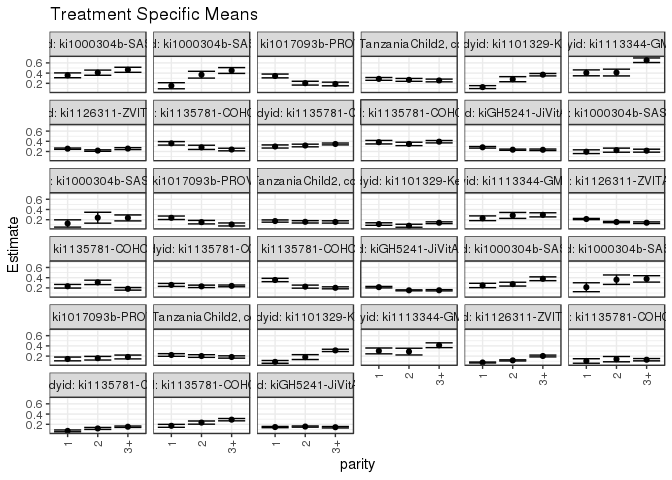

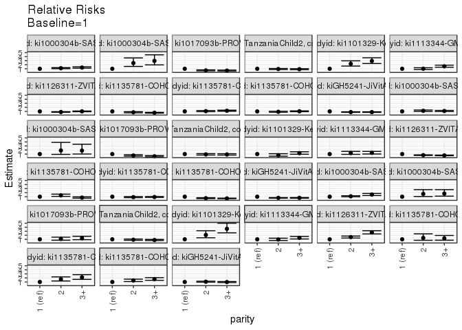

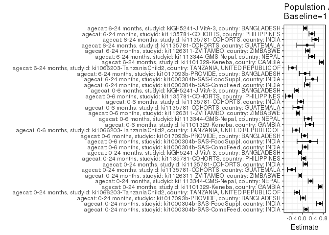

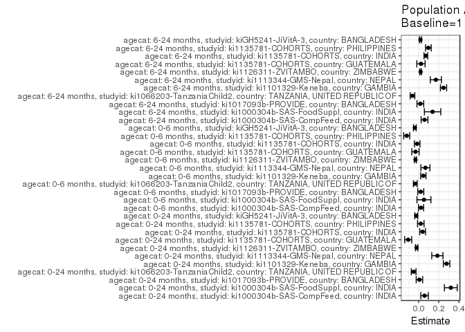

## Results Table

### Parameter: TSM

| agecat | studyid | country | intervention_level | baseline_level | estimate | ci_lower | ci_upper |
| --- | --- | --- | --- | --- | --- | --- | --- |
| 0-24 months | ki1000304b-SAS-CompFeed | INDIA | 1 | NA | 0.3566042 | 0.3094379 | 0.4037704 |
| 0-24 months | ki1000304b-SAS-CompFeed | INDIA | 2 | NA | 0.4081894 | 0.3577194 | 0.4586594 |
| 0-24 months | ki1000304b-SAS-CompFeed | INDIA | 3+ | NA | 0.4650087 | 0.4158878 | 0.5141297 |
| 0-24 months | ki1000304b-SAS-FoodSuppl | INDIA | 1 | NA | 0.1528846 | 0.0936310 | 0.2121382 |
| 0-24 months | ki1000304b-SAS-FoodSuppl | INDIA | 2 | NA | 0.3687348 | 0.3018503 | 0.4356193 |
| 0-24 months | ki1000304b-SAS-FoodSuppl | INDIA | 3+ | NA | 0.4511573 | 0.3944465 | 0.5078681 |
| 0-24 months | ki1017093b-PROVIDE | BANGLADESH | 1 | NA | 0.3440747 | 0.3068894 | 0.3812601 |
| 0-24 months | ki1017093b-PROVIDE | BANGLADESH | 2 | NA | 0.2029692 | 0.1657982 | 0.2401402 |
| 0-24 months | ki1017093b-PROVIDE | BANGLADESH | 3+ | NA | 0.1873496 | 0.1516752 | 0.2230240 |
| 0-24 months | ki1066203-TanzaniaChild2 | TANZANIA, UNITED REPUBLIC OF | 1 | NA | 0.2869636 | 0.2596296 | 0.3142977 |
| 0-24 months | ki1066203-TanzaniaChild2 | TANZANIA, UNITED REPUBLIC OF | 2 | NA | 0.2676157 | 0.2397555 | 0.2954759 |
| 0-24 months | ki1066203-TanzaniaChild2 | TANZANIA, UNITED REPUBLIC OF | 3+ | NA | 0.2556508 | 0.2289424 | 0.2823593 |
| 0-24 months | ki1101329-Keneba | GAMBIA | 1 | NA | 0.1262145 | 0.0974140 | 0.1550151 |
| 0-24 months | ki1101329-Keneba | GAMBIA | 2 | NA | 0.2807799 | 0.2309904 | 0.3305694 |
| 0-24 months | ki1101329-Keneba | GAMBIA | 3+ | NA | 0.3691604 | 0.3455514 | 0.3927693 |
| 0-24 months | ki1113344-GMS-Nepal | NEPAL | 1 | NA | 0.4050978 | 0.3472594 | 0.4629362 |
| 0-24 months | ki1113344-GMS-Nepal | NEPAL | 2 | NA | 0.4107544 | 0.3445466 | 0.4769622 |
| 0-24 months | ki1113344-GMS-Nepal | NEPAL | 3+ | NA | 0.6518965 | 0.6070514 | 0.6967416 |
| 0-24 months | ki1126311-ZVITAMBO | ZIMBABWE | 1 | NA | 0.2555449 | 0.2426061 | 0.2684836 |
| 0-24 months | ki1126311-ZVITAMBO | ZIMBABWE | 2 | NA | 0.2184019 | 0.2043902 | 0.2324137 |
| 0-24 months | ki1126311-ZVITAMBO | ZIMBABWE | 3+ | NA | 0.2572978 | 0.2382863 | 0.2763093 |
| 0-24 months | ki1135781-COHORTS | GUATEMALA | 1 | NA | 0.3597025 | 0.3254265 | 0.3939784 |
| 0-24 months | ki1135781-COHORTS | GUATEMALA | 2 | NA | 0.2814942 | 0.2402035 | 0.3227849 |
| 0-24 months | ki1135781-COHORTS | GUATEMALA | 3+ | NA | 0.2388637 | 0.2135730 | 0.2641543 |
| 0-24 months | ki1135781-COHORTS | INDIA | 1 | NA | 0.2987360 | 0.2685269 | 0.3289452 |
| 0-24 months | ki1135781-COHORTS | INDIA | 2 | NA | 0.3177110 | 0.2913272 | 0.3440947 |
| 0-24 months | ki1135781-COHORTS | INDIA | 3+ | NA | 0.3475351 | 0.3291593 | 0.3659108 |
| 0-24 months | ki1135781-COHORTS | PHILIPPINES | 1 | NA | 0.3827069 | 0.3484031 | 0.4170107 |
| 0-24 months | ki1135781-COHORTS | PHILIPPINES | 2 | NA | 0.3485559 | 0.3149880 | 0.3821238 |
| 0-24 months | ki1135781-COHORTS | PHILIPPINES | 3+ | NA | 0.3923108 | 0.3688401 | 0.4157814 |

[output cut: 69 more lines]

### Parameter: E(Y)

| agecat | studyid | country | intervention_level | baseline_level | estimate | ci_lower | ci_upper |
| --- | --- | --- | --- | --- | --- | --- | --- |
| 0-24 months | ki1000304b-SAS-CompFeed | INDIA | NA | NA | 0.4150694 | 0.3581204 | 0.4720184 |
| 0-24 months | ki1000304b-SAS-FoodSuppl | INDIA | NA | NA | 0.4735516 | 0.4243746 | 0.5227286 |
| 0-24 months | ki1017093b-PROVIDE | BANGLADESH | NA | NA | 0.3514286 | 0.3160364 | 0.3868207 |
| 0-24 months | ki1066203-TanzaniaChild2 | TANZANIA, UNITED REPUBLIC OF | NA | NA | 0.2367416 | 0.2195770 | 0.2539062 |
| 0-24 months | ki1101329-Keneba | GAMBIA | NA | NA | 0.4042232 | 0.3826511 | 0.4257953 |
| 0-24 months | ki1113344-GMS-Nepal | NEPAL | NA | NA | 0.5913621 | 0.5520608 | 0.6306634 |
| 0-24 months | ki1126311-ZVITAMBO | ZIMBABWE | NA | NA | 0.2347539 | 0.2277172 | 0.2417906 |
| 0-24 months | ki1135781-COHORTS | GUATEMALA | NA | NA | 0.2550336 | 0.2316956 | 0.2783715 |
| 0-24 months | ki1135781-COHORTS | INDIA | NA | NA | 0.3378028 | 0.3241691 | 0.3514364 |
| 0-24 months | ki1135781-COHORTS | PHILIPPINES | NA | NA | 0.4036125 | 0.3861835 | 0.4210415 |
| 0-24 months | kiGH5241-JiVitA-3 | BANGLADESH | NA | NA | 0.2581952 | 0.2517314 | 0.2646590 |
| 0-6 months | ki1000304b-SAS-CompFeed | INDIA | NA | NA | 0.2199336 | 0.1753445 | 0.2645227 |
| 0-6 months | ki1000304b-SAS-FoodSuppl | INDIA | NA | NA | 0.1788413 | 0.1410973 | 0.2165853 |
| 0-6 months | ki1017093b-PROVIDE | BANGLADESH | NA | NA | 0.2585714 | 0.2261125 | 0.2910304 |
| 0-6 months | ki1066203-TanzaniaChild2 | TANZANIA, UNITED REPUBLIC OF | NA | NA | 0.1395842 | 0.1255905 | 0.1535779 |
| 0-6 months | ki1101329-Keneba | GAMBIA | NA | NA | 0.1613611 | 0.1444653 | 0.1782570 |
| 0-6 months | ki1113344-GMS-Nepal | NEPAL | NA | NA | 0.2956811 | 0.2591967 | 0.3321655 |
| 0-6 months | ki1126311-ZVITAMBO | ZIMBABWE | NA | NA | 0.1810631 | 0.1746489 | 0.1874773 |
| 0-6 months | ki1135781-COHORTS | GUATEMALA | NA | NA | 0.2003763 | 0.1763021 | 0.2244505 |
| 0-6 months | ki1135781-COHORTS | INDIA | NA | NA | 0.2434743 | 0.2308547 | 0.2560940 |
| 0-6 months | ki1135781-COHORTS | PHILIPPINES | NA | NA | 0.2355453 | 0.2204685 | 0.2506222 |
| 0-6 months | kiGH5241-JiVitA-3 | BANGLADESH | NA | NA | 0.1762799 | 0.1706566 | 0.1819032 |
| 6-24 months | ki1000304b-SAS-CompFeed | INDIA | NA | NA | 0.3059755 | 0.2638053 | 0.3481458 |
| 6-24 months | ki1000304b-SAS-FoodSuppl | INDIA | NA | NA | 0.3518987 | 0.3047435 | 0.3990540 |
| 6-24 months | ki1017093b-PROVIDE | BANGLADESH | NA | NA | 0.1609756 | 0.1319065 | 0.1900447 |
| 6-24 months | ki1066203-TanzaniaChild2 | TANZANIA, UNITED REPUBLIC OF | NA | NA | 0.1600403 | 0.1439152 | 0.1761654 |
| 6-24 months | ki1101329-Keneba | GAMBIA | NA | NA | 0.3341996 | 0.3131165 | 0.3552826 |
| 6-24 months | ki1113344-GMS-Nepal | NEPAL | NA | NA | 0.4728814 | 0.4325613 | 0.5132014 |
| 6-24 months | ki1126311-ZVITAMBO | ZIMBABWE | NA | NA | 0.0939867 | 0.0884555 | 0.0995179 |
| 6-24 months | ki1135781-COHORTS | GUATEMALA | NA | NA | 0.1269580 | 0.1082147 | 0.1457012 |
| 6-24 months | ki1135781-COHORTS | INDIA | NA | NA | 0.1419682 | 0.1315821 | 0.1523542 |
| 6-24 months | ki1135781-COHORTS | PHILIPPINES | NA | NA | 0.2666429 | 0.2502871 | 0.2829988 |
| 6-24 months | kiGH5241-JiVitA-3 | BANGLADESH | NA | NA | 0.1639050 | 0.1577770 | 0.1700330 |

### Parameter: RR

| agecat | studyid | country | intervention_level | baseline_level | estimate | ci_lower | ci_upper |
| --- | --- | --- | --- | --- | --- | --- | --- |
| 0-24 months | ki1000304b-SAS-CompFeed | INDIA | 1 | 1 | 1.0000000 | 1.0000000 | 1.0000000 |
| 0-24 months | ki1000304b-SAS-CompFeed | INDIA | 2 | 1 | 1.1446569 | 1.0251247 | 1.2781268 |
| 0-24 months | ki1000304b-SAS-CompFeed | INDIA | 3+ | 1 | 1.3039913 | 1.1445443 | 1.4856509 |
| 0-24 months | ki1000304b-SAS-FoodSuppl | INDIA | 1 | 1 | 1.0000000 | 1.0000000 | 1.0000000 |
| 0-24 months | ki1000304b-SAS-FoodSuppl | INDIA | 2 | 1 | 2.4118503 | 1.5806908 | 3.6800505 |
| 0-24 months | ki1000304b-SAS-FoodSuppl | INDIA | 3+ | 1 | 2.9509663 | 1.9575019 | 4.4486304 |
| 0-24 months | ki1017093b-PROVIDE | BANGLADESH | 1 | 1 | 1.0000000 | 1.0000000 | 1.0000000 |
| 0-24 months | ki1017093b-PROVIDE | BANGLADESH | 2 | 1 | 0.5898985 | 0.4777402 | 0.7283881 |
| 0-24 months | ki1017093b-PROVIDE | BANGLADESH | 3+ | 1 | 0.5445026 | 0.4370198 | 0.6784202 |
| 0-24 months | ki1066203-TanzaniaChild2 | TANZANIA, UNITED REPUBLIC OF | 1 | 1 | 1.0000000 | 1.0000000 | 1.0000000 |
| 0-24 months | ki1066203-TanzaniaChild2 | TANZANIA, UNITED REPUBLIC OF | 2 | 1 | 0.9325771 | 0.8108382 | 1.0725939 |
| 0-24 months | ki1066203-TanzaniaChild2 | TANZANIA, UNITED REPUBLIC OF | 3+ | 1 | 0.8908824 | 0.7735668 | 1.0259895 |
| 0-24 months | ki1101329-Keneba | GAMBIA | 1 | 1 | 1.0000000 | 1.0000000 | 1.0000000 |
| 0-24 months | ki1101329-Keneba | GAMBIA | 2 | 1 | 2.2246243 | 1.6683505 | 2.9663750 |
| 0-24 months | ki1101329-Keneba | GAMBIA | 3+ | 1 | 2.9248643 | 2.3020179 | 3.7162313 |
| 0-24 months | ki1113344-GMS-Nepal | NEPAL | 1 | 1 | 1.0000000 | 1.0000000 | 1.0000000 |
| 0-24 months | ki1113344-GMS-Nepal | NEPAL | 2 | 1 | 1.0139636 | 0.8189414 | 1.2554284 |
| 0-24 months | ki1113344-GMS-Nepal | NEPAL | 3+ | 1 | 1.6092326 | 1.3738868 | 1.8848928 |
| 0-24 months | ki1126311-ZVITAMBO | ZIMBABWE | 1 | 1 | 1.0000000 | 1.0000000 | 1.0000000 |
| 0-24 months | ki1126311-ZVITAMBO | ZIMBABWE | 2 | 1 | 0.8546521 | 0.7876935 | 0.9273025 |
| 0-24 months | ki1126311-ZVITAMBO | ZIMBABWE | 3+ | 1 | 1.0068596 | 0.9206986 | 1.1010837 |
| 0-24 months | ki1135781-COHORTS | GUATEMALA | 1 | 1 | 1.0000000 | 1.0000000 | 1.0000000 |
| 0-24 months | ki1135781-COHORTS | GUATEMALA | 2 | 1 | 0.7825752 | 0.6574942 | 0.9314514 |
| 0-24 months | ki1135781-COHORTS | GUATEMALA | 3+ | 1 | 0.6640590 | 0.5771234 | 0.7640903 |
| 0-24 months | ki1135781-COHORTS | INDIA | 1 | 1 | 1.0000000 | 1.0000000 | 1.0000000 |
| 0-24 months | ki1135781-COHORTS | INDIA | 2 | 1 | 1.0635174 | 0.9331810 | 1.2120578 |
| 0-24 months | ki1135781-COHORTS | INDIA | 3+ | 1 | 1.1633517 | 1.0379749 | 1.3038727 |
| 0-24 months | ki1135781-COHORTS | PHILIPPINES | 1 | 1 | 1.0000000 | 1.0000000 | 1.0000000 |
| 0-24 months | ki1135781-COHORTS | PHILIPPINES | 2 | 1 | 0.9107646 | 0.7986794 | 1.0385798 |
| 0-24 months | ki1135781-COHORTS | PHILIPPINES | 3+ | 1 | 1.0250946 | 0.9203364 | 1.1417771 |

[output cut: 69 more lines]

### Parameter: PAR

| agecat | studyid | country | intervention_level | baseline_level | estimate | ci_lower | ci_upper |
| --- | --- | --- | --- | --- | --- | --- | --- |
| 0-24 months | ki1000304b-SAS-CompFeed | INDIA | 1 | NA | 0.0584652 | 0.0210888 | 0.0958417 |
| 0-24 months | ki1000304b-SAS-FoodSuppl | INDIA | 1 | NA | 0.3206670 | 0.2567859 | 0.3845481 |
| 0-24 months | ki1017093b-PROVIDE | BANGLADESH | 1 | NA | 0.0073538 | -0.0248827 | 0.0395903 |
| 0-24 months | ki1066203-TanzaniaChild2 | TANZANIA, UNITED REPUBLIC OF | 1 | NA | -0.0502220 | -0.0738389 | -0.0266051 |
| 0-24 months | ki1101329-Keneba | GAMBIA | 1 | NA | 0.2780087 | 0.2456542 | 0.3103632 |
| 0-24 months | ki1113344-GMS-Nepal | NEPAL | 1 | NA | 0.1862643 | 0.1303367 | 0.2421919 |
| 0-24 months | ki1126311-ZVITAMBO | ZIMBABWE | 1 | NA | -0.0207909 | -0.0320382 | -0.0095437 |
| 0-24 months | ki1135781-COHORTS | GUATEMALA | 1 | NA | -0.1046689 | -0.1395572 | -0.0697806 |
| 0-24 months | ki1135781-COHORTS | INDIA | 1 | NA | 0.0390667 | 0.0102606 | 0.0678729 |
| 0-24 months | ki1135781-COHORTS | PHILIPPINES | 1 | NA | 0.0209056 | -0.0115156 | 0.0533268 |
| 0-24 months | kiGH5241-JiVitA-3 | BANGLADESH | 1 | NA | -0.0245521 | -0.0388818 | -0.0102224 |
| 0-6 months | ki1000304b-SAS-CompFeed | INDIA | 1 | NA | 0.0235792 | -0.0023857 | 0.0495441 |
| 0-6 months | ki1000304b-SAS-FoodSuppl | INDIA | 1 | NA | 0.0524290 | -0.0170881 | 0.1219462 |
| 0-6 months | ki1017093b-PROVIDE | BANGLADESH | 1 | NA | 0.0207114 | -0.0093364 | 0.0507592 |
| 0-6 months | ki1066203-TanzaniaChild2 | TANZANIA, UNITED REPUBLIC OF | 1 | NA | -0.0340796 | -0.0528847 | -0.0152746 |
| 0-6 months | ki1101329-Keneba | GAMBIA | 1 | NA | 0.0465051 | 0.0204453 | 0.0725649 |
| 0-6 months | ki1113344-GMS-Nepal | NEPAL | 1 | NA | 0.0672928 | 0.0223744 | 0.1122113 |
| 0-6 months | ki1126311-ZVITAMBO | ZIMBABWE | 1 | NA | -0.0323455 | -0.0425893 | -0.0221017 |
| 0-6 months | ki1135781-COHORTS | GUATEMALA | 1 | NA | -0.0319676 | -0.0683351 | 0.0043998 |
| 0-6 months | ki1135781-COHORTS | INDIA | 1 | NA | -0.0150582 | -0.0426420 | 0.0125255 |
| 0-6 months | ki1135781-COHORTS | PHILIPPINES | 1 | NA | -0.1192423 | -0.1493896 | -0.0890950 |
| 0-6 months | kiGH5241-JiVitA-3 | BANGLADESH | 1 | NA | -0.0383592 | -0.0519862 | -0.0247322 |
| 6-24 months | ki1000304b-SAS-CompFeed | INDIA | 1 | NA | 0.0579735 | 0.0242635 | 0.0916835 |
| 6-24 months | ki1000304b-SAS-FoodSuppl | INDIA | 1 | NA | 0.1384920 | 0.0568649 | 0.2201191 |
| 6-24 months | ki1017093b-PROVIDE | BANGLADESH | 1 | NA | 0.0166403 | -0.0167907 | 0.0500712 |
| 6-24 months | ki1066203-TanzaniaChild2 | TANZANIA, UNITED REPUBLIC OF | 1 | NA | -0.0617249 | -0.0845162 | -0.0389336 |
| 6-24 months | ki1101329-Keneba | GAMBIA | 1 | NA | 0.2476038 | 0.2166598 | 0.2785478 |
| 6-24 months | ki1113344-GMS-Nepal | NEPAL | 1 | NA | 0.1714689 | 0.1160749 | 0.2268629 |
| 6-24 months | ki1126311-ZVITAMBO | ZIMBABWE | 1 | NA | 0.0191718 | 0.0110426 | 0.0273011 |
| 6-24 months | ki1135781-COHORTS | GUATEMALA | 1 | NA | 0.0227956 | -0.0185204 | 0.0641117 |
| 6-24 months | ki1135781-COHORTS | INDIA | 1 | NA | 0.0711573 | 0.0532925 | 0.0890220 |
| 6-24 months | ki1135781-COHORTS | PHILIPPINES | 1 | NA | 0.0966370 | 0.0684208 | 0.1248531 |
| 6-24 months | kiGH5241-JiVitA-3 | BANGLADESH | 1 | NA | 0.0178464 | 0.0068260 | 0.0288667 |

### Parameter: PAF

| agecat | studyid | country | intervention_level | baseline_level | estimate | ci_lower | ci_upper |
| --- | --- | --- | --- | --- | --- | --- | --- |
| 0-24 months | ki1000304b-SAS-CompFeed | INDIA | 1 | NA | 0.1408565 | 0.0562800 | 0.2178533 |
| 0-24 months | ki1000304b-SAS-FoodSuppl | INDIA | 1 | NA | 0.6771532 | 0.5335133 | 0.7765638 |
| 0-24 months | ki1017093b-PROVIDE | BANGLADESH | 1 | NA | 0.0209255 | -0.0743398 | 0.1077434 |
| 0-24 months | ki1066203-TanzaniaChild2 | TANZANIA, UNITED REPUBLIC OF | 1 | NA | -0.2121385 | -0.3195225 | -0.1134935 |
| 0-24 months | ki1101329-Keneba | GAMBIA | 1 | NA | 0.6877603 | 0.6094705 | 0.7503553 |
| 0-24 months | ki1113344-GMS-Nepal | NEPAL | 1 | NA | 0.3149751 | 0.2182448 | 0.3997365 |
| 0-24 months | ki1126311-ZVITAMBO | ZIMBABWE | 1 | NA | -0.0885649 | -0.1377728 | -0.0414851 |
| 0-24 months | ki1135781-COHORTS | GUATEMALA | 1 | NA | -0.4104123 | -0.5735412 | -0.2641950 |
| 0-24 months | ki1135781-COHORTS | INDIA | 1 | NA | 0.1156496 | 0.0266629 | 0.1965007 |
| 0-24 months | ki1135781-COHORTS | PHILIPPINES | 1 | NA | 0.0517962 | -0.0316814 | 0.1285194 |
| 0-24 months | kiGH5241-JiVitA-3 | BANGLADESH | 1 | NA | -0.0950911 | -0.1521317 | -0.0408746 |
| 0-6 months | ki1000304b-SAS-CompFeed | INDIA | 1 | NA | 0.1072107 | -0.0066505 | 0.2081932 |
| 0-6 months | ki1000304b-SAS-FoodSuppl | INDIA | 1 | NA | 0.2931595 | -0.2090447 | 0.5867618 |
| 0-6 months | ki1017093b-PROVIDE | BANGLADESH | 1 | NA | 0.0800993 | -0.0397193 | 0.1861099 |
| 0-6 months | ki1066203-TanzaniaChild2 | TANZANIA, UNITED REPUBLIC OF | 1 | NA | -0.2441511 | -0.3921250 | -0.1119059 |
| 0-6 months | ki1101329-Keneba | GAMBIA | 1 | NA | 0.2882049 | 0.1192768 | 0.4247315 |
| 0-6 months | ki1113344-GMS-Nepal | NEPAL | 1 | NA | 0.2275859 | 0.0691284 | 0.3590699 |
| 0-6 months | ki1126311-ZVITAMBO | ZIMBABWE | 1 | NA | -0.1786422 | -0.2371124 | -0.1229355 |
| 0-6 months | ki1135781-COHORTS | GUATEMALA | 1 | NA | -0.1595380 | -0.3651435 | 0.0151010 |
| 0-6 months | ki1135781-COHORTS | INDIA | 1 | NA | -0.0618474 | -0.1817873 | 0.0459198 |
| 0-6 months | ki1135781-COHORTS | PHILIPPINES | 1 | NA | -0.5062393 | -0.6472492 | -0.3773004 |
| 0-6 months | kiGH5241-JiVitA-3 | BANGLADESH | 1 | NA | -0.2176041 | -0.2979977 | -0.1421897 |
| 6-24 months | ki1000304b-SAS-CompFeed | INDIA | 1 | NA | 0.1894709 | 0.0798064 | 0.2860661 |
| 6-24 months | ki1000304b-SAS-FoodSuppl | INDIA | 1 | NA | 0.3935564 | 0.1145170 | 0.5846630 |
| 6-24 months | ki1017093b-PROVIDE | BANGLADESH | 1 | NA | 0.1033714 | -0.1240469 | 0.2847782 |
| 6-24 months | ki1066203-TanzaniaChild2 | TANZANIA, UNITED REPUBLIC OF | 1 | NA | -0.3856835 | -0.5470518 | -0.2411471 |
| 6-24 months | ki1101329-Keneba | GAMBIA | 1 | NA | 0.7408860 | 0.6480222 | 0.8092492 |
| 6-24 months | ki1113344-GMS-Nepal | NEPAL | 1 | NA | 0.3626046 | 0.2411886 | 0.4645930 |
| 6-24 months | ki1126311-ZVITAMBO | ZIMBABWE | 1 | NA | 0.2039844 | 0.1141004 | 0.2847488 |
| 6-24 months | ki1135781-COHORTS | GUATEMALA | 1 | NA | 0.1795525 | -0.2185921 | 0.4476133 |
| 6-24 months | ki1135781-COHORTS | INDIA | 1 | NA | 0.5012199 | 0.3658871 | 0.6076698 |
| 6-24 months | ki1135781-COHORTS | PHILIPPINES | 1 | NA | 0.3624210 | 0.2511916 | 0.4571281 |
| 6-24 months | kiGH5241-JiVitA-3 | BANGLADESH | 1 | NA | 0.1088825 | 0.0391979 | 0.1735130 |